# 韓國瑜 & 陳其邁 2018 年 9 月臉書資料文本分析

## 檢查一下目前的詞頻排序，分別排出各 page 的前 20 大詞頻字

```r
HCmessageAll$Page_Name[1]
```

```
## [1] "韓國瑜"
```

```r
HC1 = head(sort(table(segment[[1]]), decreasing=T), 20)
HC1
```

```
##
##   高雄 年輕人   我們   一起   不是   不要   未來   因為   領導   一個
##     10      6      6      4      4      4      4      4      4      3
##   一樣 主持人   以及   目標   成為   你們   那天   來到   建設   純粹
##      3      3      3      3      3      3      3      3      3      3
```

```r
HCmessageAll$Page_Name[2]
```

```
## [1] "高雄選韓國瑜News"
```

```r
HC2 = head(sort(table(segment[[2]]), decreasing=T), 20)
HC2
```

```
##
## 韓國瑜   高雄 民進黨 高雄市   大家   支持   選舉   可以   市長   經濟
##     62     24     20     19     16     11     10      9      9      9
##   抹黑   林區   軍人   員工 理事長   農民   不會 中秋節   相信   奧步
##      8      8      8      8      7      7      6      6      6      6
```

```r
HCmessageAll$Page_Name[3]
```

```
## [1] "韓國瑜民間粉絲團（志工團"
```

```r
HC3 = head(sort(table(segment[[3]]), decreasing=T), 20)
HC3
```

```
##
## 韓國瑜   住民   高雄   市長 高雄市   經濟   政見   鄉親   增加   工作
##     37     15     11      9      9      7      5      5      5      4
##   六龜   母語   一個   支持   他們   台灣   未來 民進黨   沒有   協調
##      4      4      3      3      3      3      3      3      3      3
```

```r
HCmessageAll$Page_Name[4]
```

```
## [1] "陳其邁 Chen Chi-Mai"
```

```r
HC4 = head(sort(table(segment[[4]]), decreasing=T), 20)
HC4
```

```
##
##   高雄   其邁   市長   醫療   未來   相信 高雄市   標準   發展   台灣
##     75     58     42     36     30     27     26     22     20     18
##   看好   直播   支持   城市   市民   我們   一起   官方   捐款   道路
##     18     17     16     16     15     15     14     14     14     14
```

## 將各 page 中的前二十大詞頻字進行聯集，建立 term-document matrix

```r
tempTAB_R = merge(x = HC1, y = HC2, by = "Var1", all = TRUE)
tempTAB_L = merge(x = HC3, y = HC4, by = "Var1", all = TRUE)
NewTAB = merge(x = tempTAB_R, y = tempTAB_L, by = "Var1", all = TRUE)
colnames(NewTAB) = c("words", HCmessageAll$Page_Name)
rownames(NewTAB) = NewTAB$words
NewTAB = NewTAB[,-1]
NewTAB[is.na(NewTAB)] <- 0
kable(NewTAB)
```

|  | 韓國瑜 | 高雄選韓國瑜News | 韓國瑜民間粉絲團（志工團 | 陳其邁 Chen Chi-Mai |
| --- | --- | --- | --- | --- |
| 高雄 | 10 | 24 | 11 | 75 |
| 年輕人 | 6 | 0 | 0 | 0 |
| 我們 | 6 | 0 | 0 | 15 |
| 一起 | 4 | 0 | 0 | 14 |
| 不是 | 4 | 0 | 0 | 0 |
| 不要 | 4 | 0 | 0 | 0 |
| 未來 | 4 | 0 | 3 | 30 |
| 因為 | 4 | 0 | 0 | 0 |
| 領導 | 4 | 0 | 0 | 0 |
| 一個 | 3 | 0 | 3 | 0 |
| 一樣 | 3 | 0 | 0 | 0 |
| 主持人 | 3 | 0 | 0 | 0 |
| 以及 | 3 | 0 | 0 | 0 |
| 目標 | 3 | 0 | 0 | 0 |
| 成為 | 3 | 0 | 0 | 0 |
| 你們 | 3 | 0 | 0 | 0 |
| 那天 | 3 | 0 | 0 | 0 |
| 來到 | 3 | 0 | 0 | 0 |
| 建設 | 3 | 0 | 0 | 0 |
| 純粹 | 3 | 0 | 0 | 0 |
| 韓國瑜 | 0 | 62 | 37 | 0 |
| 民進黨 | 0 | 20 | 3 | 0 |
| 高雄市 | 0 | 19 | 9 | 26 |
| 大家 | 0 | 16 | 0 | 0 |
| 支持 | 0 | 11 | 3 | 16 |
| 選舉 | 0 | 10 | 0 | 0 |
| 可以 | 0 | 9 | 0 | 0 |
| 市長 | 0 | 9 | 9 | 42 |
| 經濟 | 0 | 9 | 7 | 0 |
| 抹黑 | 0 | 8 | 0 | 0 |
| 林區 | 0 | 8 | 0 | 0 |
| 軍人 | 0 | 8 | 0 | 0 |
| 員工 | 0 | 8 | 0 | 0 |
| 理事長 | 0 | 7 | 0 | 0 |
| 農民 | 0 | 7 | 0 | 0 |
| 不會 | 0 | 6 | 0 | 0 |
| 中秋節 | 0 | 6 | 0 | 0 |
| 相信 | 0 | 6 | 0 | 27 |
| 奧步 | 0 | 6 | 0 | 0 |
| 住民 | 0 | 0 | 15 | 0 |
| 政見 | 0 | 0 | 5 | 0 |
| 鄉親 | 0 | 0 | 5 | 0 |
| 增加 | 0 | 0 | 5 | 0 |
| 工作 | 0 | 0 | 4 | 0 |
| 六龜 | 0 | 0 | 4 | 0 |
| 母語 | 0 | 0 | 4 | 0 |
| 他們 | 0 | 0 | 3 | 0 |
| 台灣 | 0 | 0 | 3 | 18 |
| 沒有 | 0 | 0 | 3 | 0 |
| 協調 | 0 | 0 | 3 | 0 |
| 其邁 | 0 | 0 | 0 | 58 |
| 醫療 | 0 | 0 | 0 | 36 |
| 標準 | 0 | 0 | 0 | 22 |
| 發展 | 0 | 0 | 0 | 20 |
| 看好 | 0 | 0 | 0 | 18 |
| 直播 | 0 | 0 | 0 | 17 |
| 城市 | 0 | 0 | 0 | 16 |
| 市民 | 0 | 0 | 0 | 15 |
| 官方 | 0 | 0 | 0 | 14 |
| 捐款 | 0 | 0 | 0 | 14 |
| 道路 | 0 | 0 | 0 | 14 |

## 以此 DTM 畫出共現性關聯圖

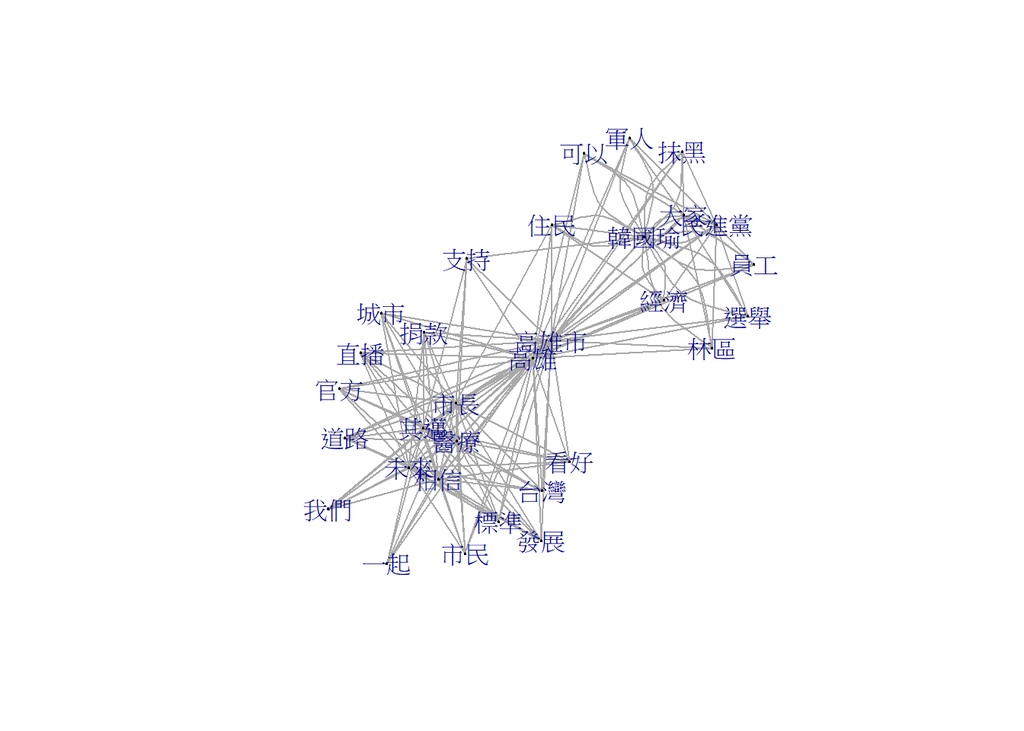

```r
CoMatrix = as.matrix(NewTAB) %*% t(as.matrix(NewTAB))
total_occurrences <- rowSums(CoMatrix)
smallid = which(total_occurrences < median(total_occurrences))
co_occurrence_d = CoMatrix / total_occurrences
co_occurrence_s = co_occurrence_d[-as.vector(smallid),-as.vector(smallid)]
require(igraph)
graph <- graph.adjacency(round(co_occurrence_s*10),
                         mode="undirected",
                         diag=FALSE)
plot(graph,
     vertex.label=names(data),
     edge.arrow.mode=0,
     vertex.size=1,
     edge.width=E(graph)$weight,
     layout=layout_with_fr)
```

觀察共現性圖與詞頻表的對照結果，韓國瑜關心的是經濟與大眾，而陳其邁對高雄市的建設雖然有許多想法，但可能因為選民對於複雜的內容越來越沒有閱讀的耐性，使得陳其邁的 video 文本分析結果，豐富的建設用詞卻無法獲得像韓國瑜一樣的回應熱烈。

```r
needTag = c("n", "v", "a")
myPOS <- function(vec) {
  TagName = names(vec)
  id = NULL
  for( i in length(needTag) ) {
    temp = which(TagName == needTag[i])
    id = c(id, temp)
  }
  result = vec[id]
}
posResult = lapply(segment, myPOS)
tempTAB_right = table(posResult[[1]])
tempTAB_left = table(posResult[[2]])
tempTAB_R = merge(x = tempTAB_right, y = tempTAB_left, by = "Var1", all = TRUE)
tempTAB_right = table(posResult[[3]])
tempTAB_left = table(posResult[[4]])
tempTAB_L = merge(x = tempTAB_right, y = tempTAB_left, by = "Var1", all = TRUE)
NewTAB = merge(x = tempTAB_R, y = tempTAB_L, by = "Var1", all = TRUE)
colnames(NewTAB) = c("words", HCmessageAll$Page_Name)
rownames(NewTAB) = NewTAB$words
NewTAB = NewTAB[,-1]
NewTAB[is.na(NewTAB)] <- 0
kable(NewTAB)
```

|  | 韓國瑜 | 高雄選韓國瑜News | 韓國瑜民間粉絲團（志工團 | 陳其邁 Chen Chi-Mai |
| --- | --- | --- | --- | --- |
| 凸顯 | 1 | 0 | 0 | 0 |
| 平凡 | 1 | 0 | 0 | 0 |
| 平安 | 1 | 0 | 0 | 0 |
| 正好 | 1 | 0 | 0 | 0 |
| 年輕 | 2 | 0 | 0 | 1 |
| 有名 | 1 | 0 | 0 | 0 |
| 壯麗 | 1 | 0 | 0 | 0 |
| 完整 | 1 | 0 | 1 | 0 |
| 沉穩 | 1 | 0 | 0 | 0 |
| 幸福 | 1 | 0 | 1 | 0 |
| 亮麗 | 1 | 0 | 0 | 0 |
| 勇敢 | 2 | 1 | 0 | 1 |
| 重要 | 2 | 2 | 0 | 6 |
| 純粹 | 3 | 0 | 0 | 0 |
| 敏惠 | 1 | 0 | 0 | 0 |
| 單純 | 3 | 0 | 0 | 0 |
| 尊重 | 1 | 0 | 0 | 0 |
| 最美 | 1 | 0 | 0 | 0 |
| 勤奮 | 1 | 0 | 0 | 0 |
| 意外 | 1 | 0 | 0 | 0 |
| 複雜 | 2 | 0 | 0 | 1 |
| 繁榮 | 1 | 0 | 1 | 4 |
| 簡單 | 3 | 0 | 0 | 0 |
| 耀眼 | 1 | 0 | 0 | 0 |
| 不大 | 0 | 1 | 0 | 0 |
| 不同 | 0 | 2 | 0 | 2 |
| 不振 | 0 | 1 | 0 | 0 |
| 充滿 | 0 | 1 | 0 | 0 |
| 平等 | 0 | 1 | 0 | 0 |
| 成功 | 0 | 1 | 0 | 1 |

[output cut: 59 more lines]

## 以此 DTM 畫出共現性關聯圖

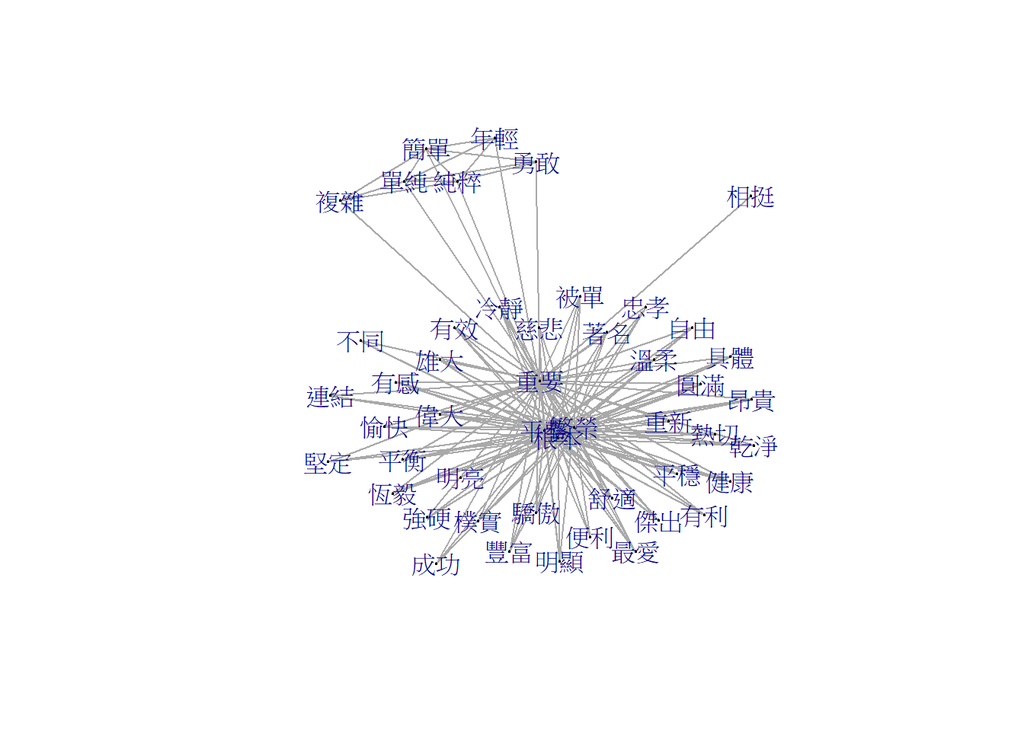

```r
CoMatrix = as.matrix(NewTAB) %*% t(as.matrix(NewTAB))
total_occurrences <- rowSums(CoMatrix)
smallid = which(total_occurrences < median(total_occurrences))
co_occurrence_d = CoMatrix / total_occurrences
co_occurrence_s = co_occurrence_d[-as.vector(smallid),-as.vector(smallid)]
require(igraph)
graph <- graph.adjacency(round(co_occurrence_s*10),
                         mode="undirected",
                         diag=FALSE)
plot(graph,
     vertex.label=names(data),
     edge.arrow.mode=0,
     vertex.size=1,
     edge.width=E(graph)$weight,
     layout=layout_with_fr)
```

觀察共現性圖與詞頻表的對照結果，韓國瑜慣用的詞彙較簡單，而陳其邁的用詞複雜，有可能因為選民對於複雜的內容越來越沒有閱讀的耐性，使得陳其邁的 video 文本分析結果，文藻華麗卻無法獲得像韓國瑜一樣的回應熱烈。